# Tidy data

Author

Denis Schluppeck

Session date:

2023-02-22

## Introduction

- a lot of data we work with is *tabular*
- can be represented in a table with *rows* and *columns*
- maybe particular important for reporting data from repeated trials, experiments, conditions (neuroscience)
- links to *statistical reports* and *visualisations* we often want/need

## Examples:

> You probably have your own, but eg:
- rating in a questionnaire [per item, participant]
- reaction times [per trial, subject, condition]
- % fMRI signal change [per brain region across, subject, conditions]
- spike rate [per neuron, animal, task]

## Just put them in a table, right!?

[figure not shown]

The files are in the computer?

## Anna Karenina principle

> “Happy families are all alike; every unhappy family is unhappy in its own way.” — Leo Tolstoy

> “Tidy datasets are all alike, but every messy dataset is messy in its own way.” — Hadley Wickham

## Example table A

number of TB cases in country, population

```r
table1 %>% gt()
```

| country | year | cases | population |
| --- | --- | --- | --- |
| Afghanistan | 1999 | 745 | 19987071 |
| Afghanistan | 2000 | 2666 | 20595360 |
| Brazil | 1999 | 37737 | 172006362 |
| Brazil | 2000 | 80488 | 174504898 |
| China | 1999 | 212258 | 1272915272 |
| China | 2000 | 213766 | 1280428583 |

## Example table B

```r
table2 %>% gt()
```

| country | year | type | count |
| --- | --- | --- | --- |
| Afghanistan | 1999 | cases | 745 |
| Afghanistan | 1999 | population | 19987071 |
| Afghanistan | 2000 | cases | 2666 |
| Afghanistan | 2000 | population | 20595360 |
| Brazil | 1999 | cases | 37737 |
| Brazil | 1999 | population | 172006362 |
| Brazil | 2000 | cases | 80488 |
| Brazil | 2000 | population | 174504898 |
| China | 1999 | cases | 212258 |
| China | 1999 | population | 1272915272 |
| China | 2000 | cases | 213766 |
| China | 2000 | population | 1280428583 |

## Example table C

```r
table3 %>% gt()
```

| country | year | rate |
| --- | --- | --- |
| Afghanistan | 1999 | 745/19987071 |
| Afghanistan | 2000 | 2666/20595360 |
| Brazil | 1999 | 37737/172006362 |
| Brazil | 2000 | 80488/174504898 |
| China | 1999 | 212258/1272915272 |
| China | 2000 | 213766/1280428583 |

## “Tidy” means

Wickham and Grolemund (2023)

Wickham, H, and G Grolemund. 2023. “R for Data Science (2e).” 2023. https://r4ds.hadley.nz/.

- each column represents a *variable*
- each row an *observation*
- each cell entry a *value* (number, text, …)

## Benefits

- this layout leads to a series of elegant ways to manipulate table
- it’s a standard (so tool builders can make code to work with it)
- it plays nicely with storage (files) and visualisation (*grammar of graphics* ideas)

## Manipulating tables: concepts

Some ideas that crop up in

- `sql`
- **`dplyr` (a popular library in `r`),**
- `pandas` (in `python`)
- `QueryVerse.jl` (in `julia`)
- `tables` in `matlab`

## Main ideas

A really good summary on [this cheatsheet](https://github.com/rstudio/cheatsheets/blob/main/data-transformation.pdf) – using `r` syntax, but good for ideas!

- subsetting (rows, columns)
- mutating (calculating new values)
- aggregating (grouping, summarising)
- combining (including *relational* data, `join()`)

## taking rows, `filter()`

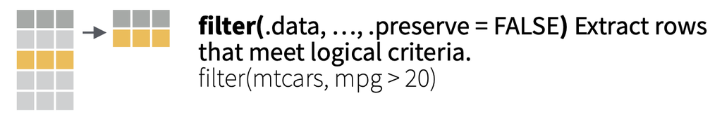

## taking columns, `select()`

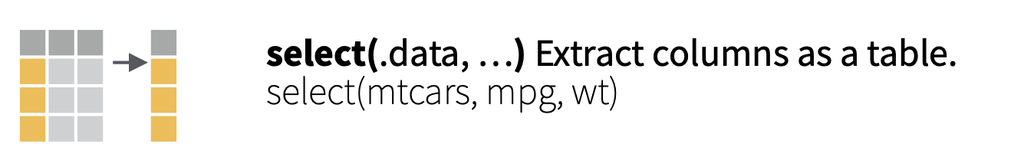

## aggregate, `groupby(), summarize()`

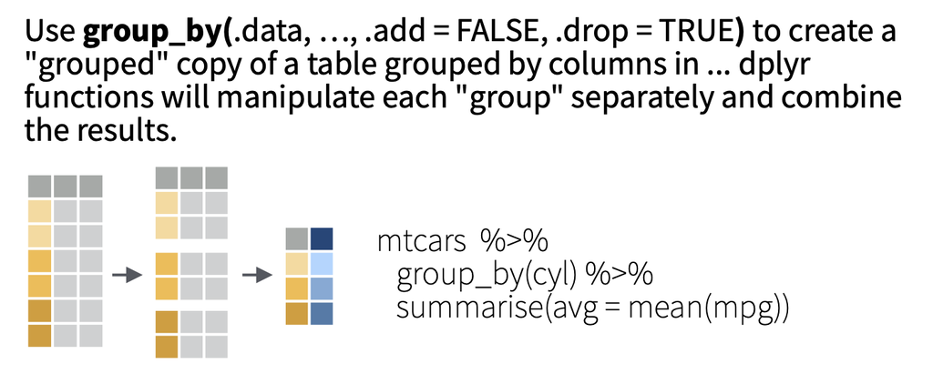

## By example (Psychophysics data)

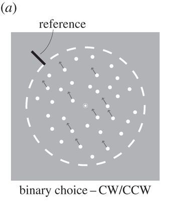

## As a table

```r
d |> gt()
```

| direction | p_cw | se | coherence | subject |
| --- | --- | --- | --- | --- |
| -19.5 | 0.114 | 0.023 | 0.04 | A |
| -15.5 | 0.173 | 0.030 | 0.04 | A |
| -11.5 | 0.236 | 0.032 | 0.04 | A |
| -7.5 | 0.276 | 0.033 | 0.04 | A |
| -3.5 | 0.390 | 0.036 | 0.04 | A |
| 0.5 | 0.430 | 0.037 | 0.04 | A |
| 4.5 | 0.516 | 0.037 | 0.04 | A |
| 8.5 | 0.599 | 0.035 | 0.04 | A |
| 12.5 | 0.719 | 0.033 | 0.04 | A |
| 16.5 | 0.748 | 0.031 | 0.04 | A |
| 20.5 | 0.780 | 0.031 | 0.04 | A |
| -19.5 | 0.048 | 0.016 | 0.07 | A |
| -15.5 | 0.089 | 0.021 | 0.07 | A |
| -11.5 | 0.106 | 0.023 | 0.07 | A |
| -7.5 | 0.152 | 0.026 | 0.07 | A |
| -3.5 | 0.304 | 0.034 | 0.07 | A |
| 0.5 | 0.397 | 0.036 | 0.07 | A |
| 4.5 | 0.592 | 0.034 | 0.07 | A |
| 8.5 | 0.695 | 0.033 | 0.07 | A |
| 12.5 | 0.823 | 0.029 | 0.07 | A |
| 16.5 | 0.831 | 0.029 | 0.07 | A |
| 20.5 | 0.923 | 0.021 | 0.07 | A |
| -19.5 | 0.010 | 0.007 | 0.13 | A |
| -15.5 | 0.049 | 0.015 | 0.13 | A |
| -11.5 | 0.098 | 0.022 | 0.13 | A |
| -7.5 | 0.121 | 0.024 | 0.13 | A |
| -3.5 | 0.218 | 0.030 | 0.13 | A |
| 0.5 | 0.424 | 0.038 | 0.13 | A |
| 4.5 | 0.611 | 0.038 | 0.13 | A |
| 8.5 | 0.715 | 0.035 | 0.13 | A |

[output cut: 190 more lines]

## `group_by` and `summarize`

- pick one coherence level
- group by direction
- summarise across all observers

````markdown
```{r}
d |> filter(coherence == 0.25) |>
     group_by(direction) |>
     summarise(mean_p_cw = mean(p_cw)) |>
     gt()
```
````

## result

```r
d |> filter(coherence == 0.25) |>
     group_by(direction) |>
     summarise(mean_p_cw = mean(p_cw)) |>
     gt()
```

| direction | mean_p_cw |
| --- | --- |
| -19.5 | 0.0498 |
| -15.5 | 0.0714 |
| -11.5 | 0.1150 |
| -7.5 | 0.1572 |
| -3.5 | 0.2898 |
| 0.5 | 0.4296 |
| 4.5 | 0.6824 |
| 8.5 | 0.8116 |
| 12.5 | 0.8662 |
| 16.5 | 0.9152 |
| 20.5 | 0.9496 |

## plotting can follow same ideas

- *declarative* style (`ggplot`) versus
- *imperative* style (`matlab`, `matplotlib`, …)[^1]

<sup>1</sup> what I used to use before I hit on / read the `tidyverse` stuff.

## plot example

5,6 lines of code to get this

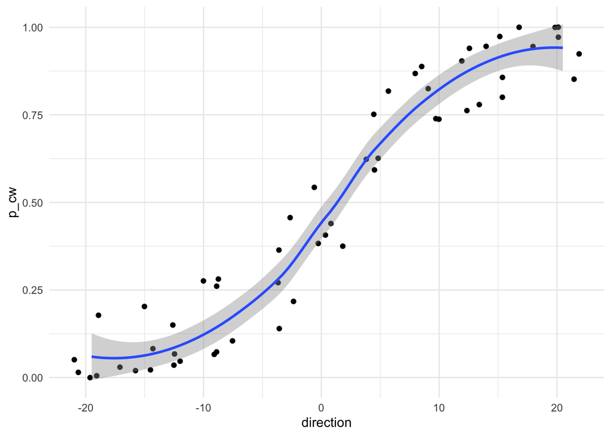

```r
d |> filter(coherence == 0.25) |>
     ggplot(aes(x = direction, y = p_cw)) +
      geom_jitter() +
      geom_smooth() +
      theme_minimal()
```

## **one** additional line…

````markdown
```{r}
      ...
      facet_wrap(~subject) +
      ...
```
````

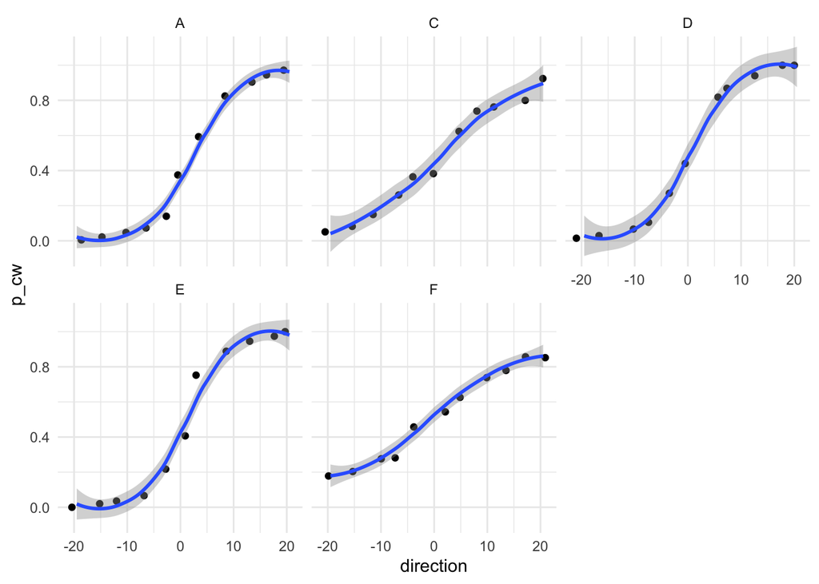

```r
d |> filter(coherence == 0.25) |>
     ggplot(aes(x = direction, y = p_cw)) +
      geom_jitter() +
      geom_smooth() +
      facet_wrap(~subject) +
      theme_minimal()
```

## Discussion

- data files (`csv`, `parquet`, `feather` ??)
- what do people do (hand-wrap their own? other libraries)
- how uses an actual **database**?
- should we teach this at UG/PG level more??